# TP3 - Analyse en Composantes Principales

Simon Desdevises

2025-09-24

## Analyse descriptive du jeu de données

Le jeu de données représente différentes informations sur la qualité de vie de tous les pays du monde.  
On y retrouve :

- `child_mort` : Taux de mortalité infantile
- `exports` : Exportations
- `health` : Indice de santé
- `imports` : Importations
- `income` : Revenu par habitant
- `inflation` : Taux d’inflation
- `life_expec` : Espérance de vie
- `total_fer` : Taux de fertilité
- `gdpp` : PIB par habitant

## A quoi sert l’argument scale.unit dans la fonction PCA ?

L’argument `scale.unit` dans la fonction `PCA` permet de centrer et réduire les variables avant de les utiliser.  
En effet, si une variable est exprimée en milliers et l’autre en millions, la variable en millions aura un poids plus important dans l’analyse.  
Dans notre cas, nous avons des données qui ne représentent pas la même grandeur, donc nous devons centrer et réduire les variables.

## Axe à retenir ?

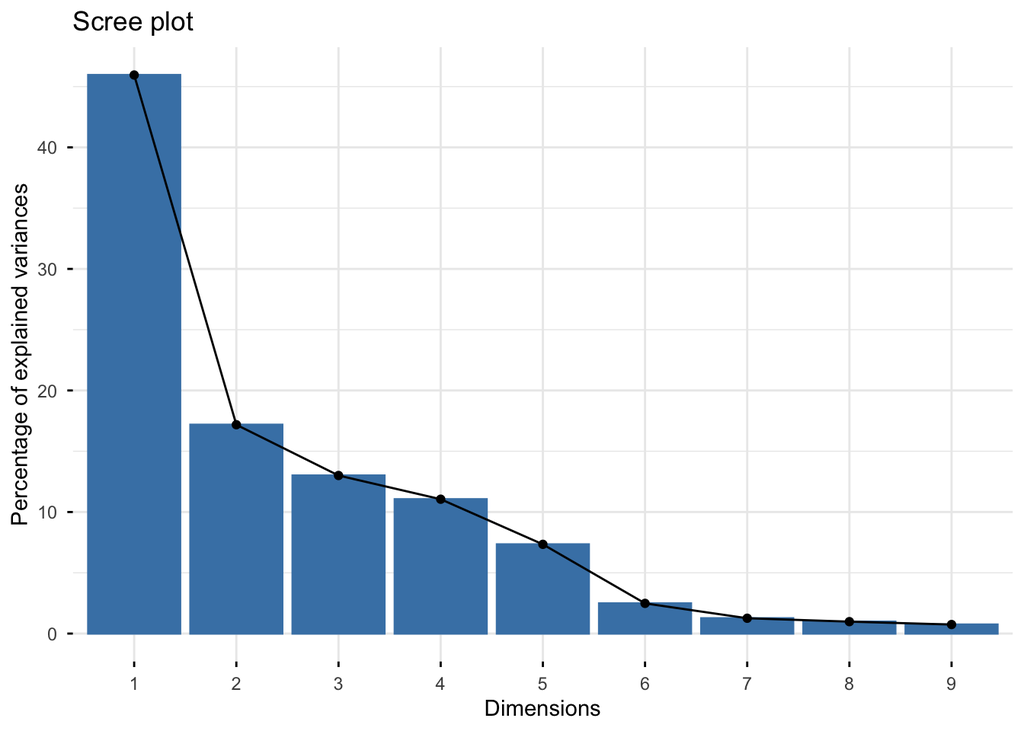

Au vu de la courbe et du critère du coude, on peut retenir les 2 premiers axes.  
Cependant si on prend le critère de Kaiser, on peut retenir 3 axes.  
Pour la suite, on retiendra les 2 premiers axes.

## Individus les mieux représentés et les plus contributeurs

### Représentation graphique des individus

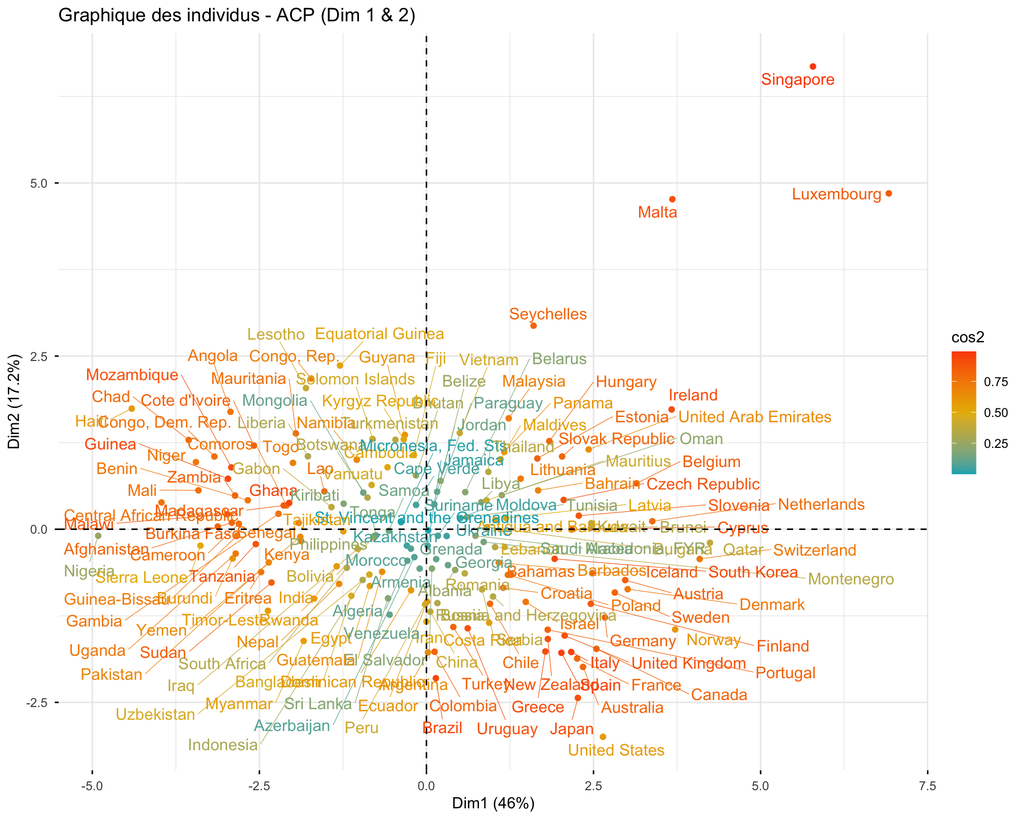

### Contribution des individus aux dimensions

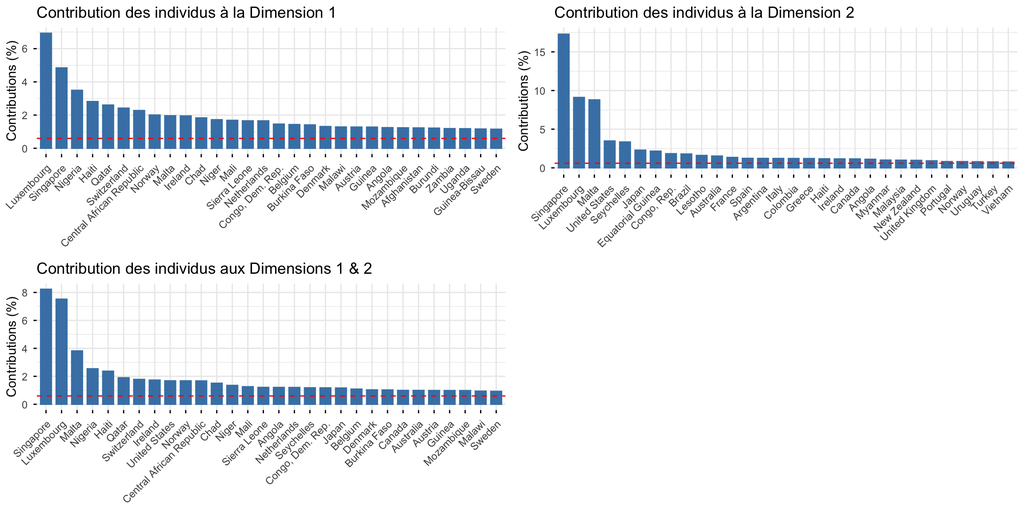

On observe que certains pays sont bien représentés sur les deux dimensions, comme *Singapour*, *Luxembourg* ou *Malte*.  
On remarque que ces pays sont de petit pays.

### Qualité de représentation des individus (cos²)

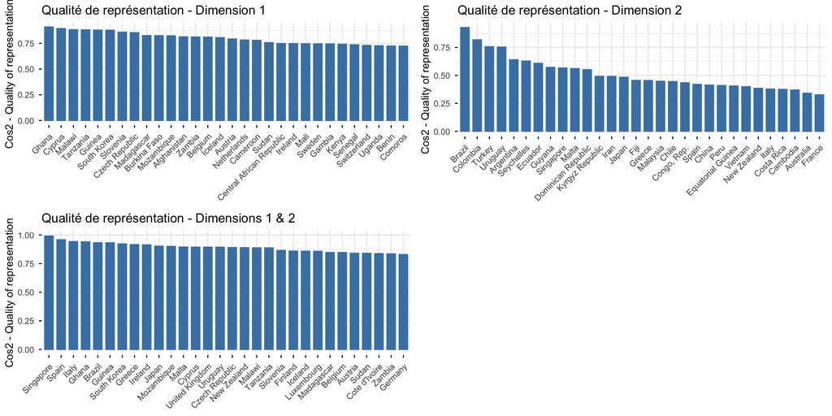

## Variables les mieux représentés et les plus contributeurs

### Contribution des variables aux dimensions

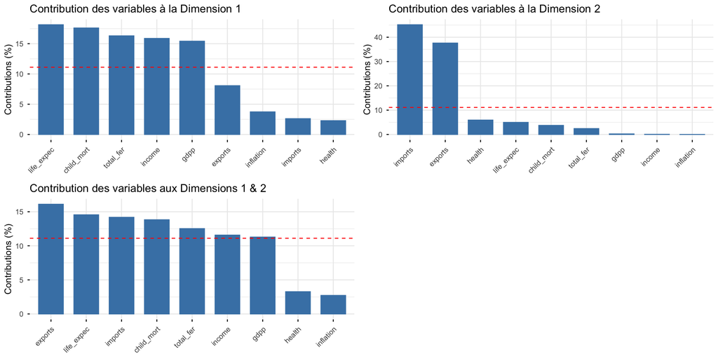

### Qualité de représentation des variables (cos²)

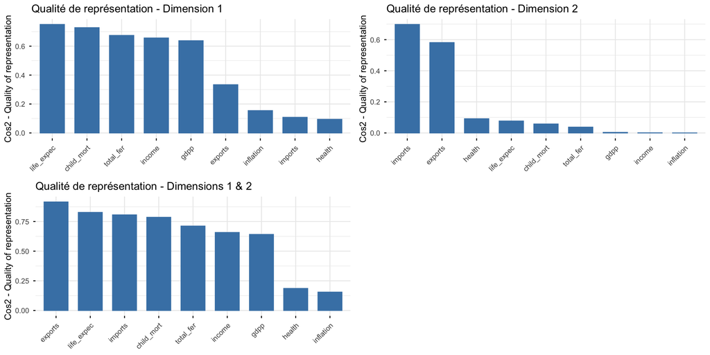

### Que représentent la variables `child_mort` ?

On observe que la variable `child_mort` est bien représentée sur la dimensions 1 et quelle a une bonne qualité. C’est même la deuxième plus haute sur cet axe  
Cependant sur la dimension 2, elle est moins bien représentée et a une qualité de représentation assez faible, largement en dessous de la moyenne. Cela est tout de même à mettre en relation avec le fait que `import` et `exports` sont les variables les plus représentées sur la dimension 2.

### Que représentent la variables `total_fer` ?

Pour ce qui est de la variable `total_fer`, elle suit la même logique que la variable `child_mort`.  
En effet, sur chaque dimension elle arrive juste derrière cette dernière.

## Interprétation des axes

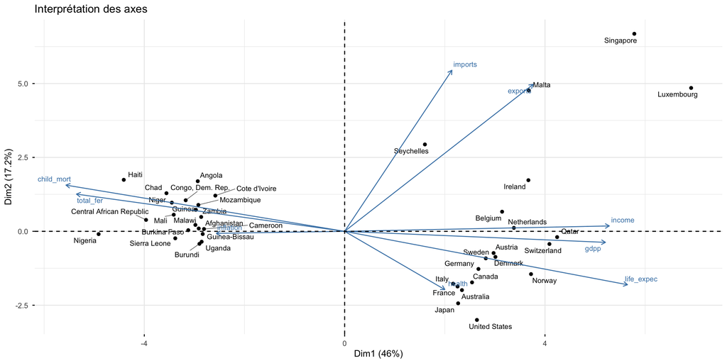

On observe que les pays les plus à gauche sont des pays Africains. Soit des pays en développement.  
A droite, nous avons des pays d’Europe occidentale et des pays d’Amérique du Nord. Soit des pays développés.  
A gauche les pays restent principales sur l’axe central. Regardons plutôt la partie droite.  
On voit que en haut il y a des pays considérés comme des paradis fiscaux tandis qu’en bas il y a les pays les plus stables et puissant.

## Si on ne centre pas les variables

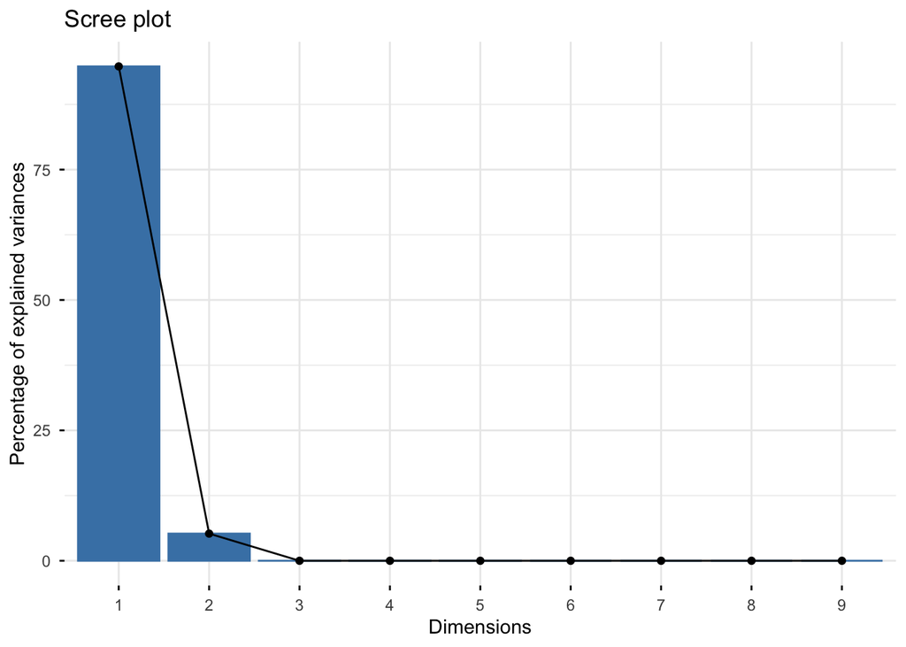